# Introduction to Text Mining

### 2018.10.29 Hanyang University

# 6. Vector Semantics

### : Dense Vector Representation

- *The Curse of Dimensionality*
- *High-Dimensional Problems: $p \gg N$*

The Elements of Statistical Learning: Data Mining, Inference, and Prediction 2E -Chapter 18 참고

Example) - 노벨경제학상, 물리학상 연설문 : $N$ = 18, $p$ = 15,594

-기업의 부도율 : 시군구지역별(230)x자산규모별(10)x매출액 규모별(10)x표준산업코드별(1,197) => 27,531,000 segments  
그런데, 우리나라 기업의 수는?

### king - man + woman = queen

[figure not shown]

# 7. 장난감 모델

## 7-1. 기업에 대한 뉴스를 통해 구축한 언어 모델

### - 2008년 12월 ~ 2016년 9월 주요 경제지의 온라인 뉴스 제목과 기업을 연결

### - 뉴스 발표일로부터 1년 이내 기업에 부도가 발생하면 부실기업 뉴스(=1)로 그렇지 않으면 정상기업 뉴스(=0)로 구분

[output not shown]

### - 년도별 정상/부실 기업 뉴스 구성

| 년도 | 정상 뉴스 수 | 부실 뉴스 수 | 합계 | 부실 뉴스 구성비 |  |
| --- | --- | --- | --- | --- | --- |
| 2008 | 13,357 | 456 | 13,813 | 3.30% |  |
| 2009 | 156,033 | 8,775 | 164,808 | 5.32% |  |
| 2010 | 155,932 | 7,850 | 163,782 | 4.79% |  |
| 2011 | 115,610 | 4,740 | 120,350 | 3.94% |  |
| 2012 | 140,945 | 5,565 | 146,510 | 3.80% |  |
| 2013 | 99,096 | 4,582 | 103,678 | 4.42% |  |
| 2014 | 95,163 | 3,092 | 98,255 | 3.15% |  |
| 2015 | 104,580 | 2,984 | 107,564 | 2.77% |  |
| 2016 | 77,581 | 2,193 | 79,774 | 2.75% |  |
| 합계 | 958,297 | 40,237 | 998,534 | 4.03% |  |

### - 년도별 정상/부실 기업 구성

| 년도 | 정상 기업 수 | 부실 기업 수 | 합계 | 부실 기업 구성비 |  |
| --- | --- | --- | --- | --- | --- |
| 2008 | 2,008 | 69 | 2,077 | 3.32% |  |
| 2009 | 5,043 | 314 | 5,357 | 5.86% |  |
| 2010 | 4,952 | 319 | 5,271 | 6.05% |  |
| 2011 | 4,352 | 233 | 4,585 | 5.08% |  |
| 2012 | 4,985 | 252 | 5,237 | 4.81% |  |
| 2013 | 4,644 | 195 | 4,839 | 4.03% |  |
| 2014 | 5,044 | 204 | 5,248 | 3.89% |  |
| 2015 | 4,999 | 182 | 5,181 | 3.51% |  |
| 2016 | 4,602 | 101 | 4,703 | 2.15% |  |

### - 년도별 부실 기업과 부실 기업 뉴스 비중

[figure not shown]

### - Word2Vec 방법으로 뉴스로부터 한국어를 학습한 toy_dense_model 을 불러와 이리저리 살펴봅시다.

주의 : 예시는 Cherry picking 결과입니다.

```python
import pickle
import pprint
from konlpy.tag import Twitter
pos_tagger = Twitter()

def tokenize(doc):
    return['/'.join(t)for t in pos_tagger.pos(doc, norm=True, stem=True)]

from gensim.models import Doc2Vec
from gensim.models.doc2vec import TaggedDocument
from collections import namedtuple
```

```python
toy_dense_model = Doc2Vec.load('Doc2Vec(dbow+w,d400,n5,hs,w5,mc5,s0.001,t8).model')
```

```python
toy_dense_model?
```

```python
pprint.pprint(toy_dense_model.wv.most_similar('매출/Noun'))
```

```
[('액/Noun', 0.5762389898300171),
 ('이익/Noun', 0.4915822148323059),
 ('익/Noun', 0.47872430086135864),
 ('영업/Noun', 0.4716307520866394),
 ('순이익/Noun', 0.4596134424209595),
 ('순익/Noun', 0.4572048783302307),
 ('사상/Noun', 0.43765807151794434),
 ('연매출/Noun', 0.4212663173675537),
 ('달성/Noun', 0.4144240915775299),
 ('당다/Verb', 0.37733155488967896)]
```

```python
pprint.pprint(toy_dense_model.wv.most_similar('부실/Noun'))
```

```
[('여신/Noun', 0.44594645500183105),
 ('PF/Alpha', 0.39537885785102844),
 ('NPL/Alpha', 0.3409172296524048),
 ('충당금/Noun', 0.3234788775444031),
 ('부동산/Noun', 0.3188086748123169),
 ('채권/Noun', 0.3164753317832947),
 ('공적자금/Noun', 0.3102889955043793),
 ('징후/Noun', 0.30630940198898315),
 ('정리/Noun', 0.30606162548065186),
 ('예보/Noun', 0.3011745512485504)]
```

```python
pprint.pprint(toy_dense_model.wv.most_similar(positive=['금리/Noun','상승/Noun'],negative=['주식/Noun'])[0])
```

```
('하락/Noun', 0.3773341774940491)
```

```python
pprint.pprint(toy_dense_model.wv.most_similar(positive=['금리/Noun','상승/Noun'],negative=['채권/Noun'])[0])
```

```
('하락/Noun', 0.39649254083633423)
```

```python
pprint.pprint(toy_dense_model.wv.most_similar(positive=['금리/Noun','하락/Noun'],negative=['채권/Noun'])[0])
```

```
('상승/Noun', 0.41907522082328796)
```

```python
pprint.pprint(toy_dense_model.wv.most_similar(positive=['금리/Noun','보합/Noun'],negative=['주식/Noun']))
```

```
[('p/Alpha', 0.372775673866272),
 ('등락/Noun', 0.3579190969467163),
 ('초반/Noun', 0.33119136095046997),
 ('중반/Noun', 0.32870686054229736),
 ('힘겨루기/Noun', 0.3249766230583191),
 ('인하/Noun', 0.31609907746315),
 ('혼/Noun', 0.3082966208457947),
 ('금리인하/Noun', 0.303908109664917),
 ('기준금리/Noun', 0.30262070894241333),
 ('1570/Number', 0.2987695038318634)]
```

```python
pprint.pprint(toy_dense_model.wv.most_similar(negative=['농심/Noun','라면/Noun'],positive=['한미/Noun'])[0])
```

```
('약품/Noun', 0.22793251276016235)
```

```python
pprint.pprint(toy_dense_model.wv.most_similar(negative=['한미/Noun','약품/Noun'],positive=['롯데/Noun'])[0])
```

```
('마트/Noun', 0.21412473917007446)
```

### - 2차원 공간에 시각화 해봅니다.

```python
# 2차원 공간에 시각화하고 싶은 문자열을 써봅니다. word tags는 무시해도 되나 값은 넣어 줍니다.
vizdt = [
         ['대형 공사계약 상한가', '2'], ['대형 매출계약 상한가 외국인 투자자 유입', '2'],
         ['업황 악화로 인한 영업부진 지속 안정성 악화', '2'],['대표이사 배임 횡령 주가 급락', '2'],
         ['법정관리와 워크아웃 기로에서 우왕좌왕', '2'],
         ['신약 개발 성공 FDA 승인 실패', '2'] ,['신약 개발 FDA 승인 성공 기대감 증대', '2']
        ]
# 시각화시키고 싶은 문자열을 한국어 품사태깅을 하여 토큰화 합니다.
doc_all   = [(tokenize(row[0]),row[1]) for row in vizdt ]
# Gensim 라이브러리가 원하는 형태로 자료를 변형시켜 줍시다.
TaggedDocumnet = namedtuple("TaggedDocument","words tags")
qlist = [TaggedDocument(a,b) for a,b in doc_all]

# toy_dense_model에 시각화 시키고 싶은 문자열을 input으로 넣어서 400 dim의 vector를 얻습니다.
viz_x = []
for doc in qlist:
    toy_dense_model.random.seed(1234)
    viz_x.append(toy_dense_model.infer_vector(doc.words))
# 입력한 문자열의 갯수와 toy_dense_model을 통해 생성한 vector의 크기를 확인해 봅니다.
print(len(viz_x), len(viz_x[0]))
```

```
7 400
```

```python
# 400 dim을 2 dim에 시각화하기 위해 PCA를 통해 축소 시켜봅니다.
import numpy as np
from sklearn.decomposition import PCA
from sklearn.preprocessing import MinMaxScaler

input_x = np.array(viz_x)

# n_components 2로 dim을 지정하고 PCA를 적용합니다.
pca = PCA(n_components=2)
pca.fit(input_x)
trf_x = pca.transform(input_x)

# 시각화를 위해 최대값, 최소값을 0~1로 스케일을 조정합니다.
min_max_scaler = MinMaxScaler()
trf_adj_x = min_max_scaler.fit_transform(trf_x)
print(trf_adj_x)
```

```
[[ 0.37837952  0.95637226]
 [ 0.4320024   1.        ]
 [ 1.          0.        ]
 [ 0.55214983  0.88746619]
 [ 0.43684095  0.72060841]
 [ 0.0473215   0.28082862]
 [ 0.          0.1185436 ]]
```

```python
# 이번에는 pandas를 이용해서 시각화를 해봅시다.
import pandas as pd
# PCA를 통해 2차원으로 변형된 데이터를 pandas DataFrame으로 바꿉니다.
value_df = pd.DataFrame(trf_adj_x, columns=['x', 'y'])
# 시각화할 문자열을 DataFrame에 추가합니다.
label = [(row[0]) for row in vizdt ]
label_df = pd.DataFrame(label, columns=['label'])
viz_df = label_df.join(value_df)
```

```python
viz_df
```

|  | label | x | y |
| --- | --- | --- | --- |
| 0 | 대형 공사계약 상한가 | 0.378380 | 0.956372 |
| 1 | 대형 매출계약 상한가 외국인 투자자 유입 | 0.432002 | 1.000000 |
| 2 | 업황 악화로 인한 영업부진 지속 안정성 악화 | 1.000000 | 0.000000 |
| 3 | 대표이사 배임 횡령 주가 급락 | 0.552150 | 0.887466 |
| 4 | 법정관리와 워크아웃 기로에서 우왕좌왕 | 0.436841 | 0.720608 |
| 5 | 신약 개발 성공 FDA 승인 실패 | 0.047321 | 0.280829 |
| 6 | 신약 개발 FDA 승인 성공 기대감 증대 | 0.000000 | 0.118544 |

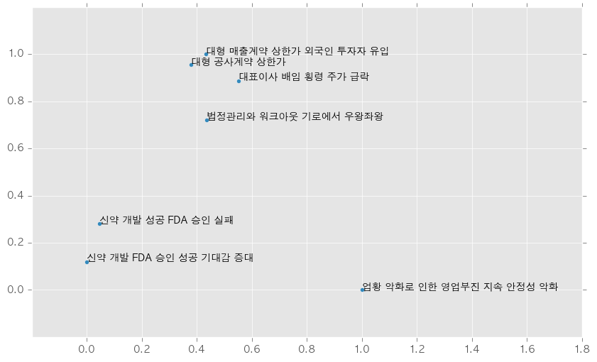

```python
%matplotlib inline
import matplotlib ; import matplotlib.pyplot as plt
from matplotlib import font_manager, rc
font_fname = '/Library/Fonts/AppleGothic.ttf' ; font_name = font_manager.FontProperties(fname=font_fname).get_name()
# C:/Windows/Fonts/Arial.ttf
rc('font', family=font_name, size=10) ; rc('figure',figsize=(10,6))
plt.style.use('ggplot')
ax = viz_df.plot('x', 'y', kind='scatter') ; viz_df[['x','y','label']].apply(lambda x: ax.text(*x),axis=1);
plt.xlabel("") ; plt.ylabel("")
plt.xticks(np.arange(0,2,0.2)) ; plt.yticks(np.arange(0,1.2,0.2))
plt.show()
```

### - toy_dense_model에게 부도 위험을 판별하게 할 수 있을까요?

```python
XY_name = {}
XY_name['train_x_Doc2Vec(dbow+w,d400,n5,hs,w5,mc5,s0.001,t8)'] = pickle.load(open('train_x_Doc2Vec(dbow+w,d400,n5,hs,w5,mc5,s0.001,t8)',"rb"))
XY_name['train_y_Doc2Vec(dbow+w,d400,n5,hs,w5,mc5,s0.001,t8)'] = pickle.load(open('train_y_Doc2Vec(dbow+w,d400,n5,hs,w5,mc5,s0.001,t8)',"rb"))
train_x = XY_name['train_x_Doc2Vec(dbow+w,d400,n5,hs,w5,mc5,s0.001,t8)']
train_y = XY_name['train_y_Doc2Vec(dbow+w,d400,n5,hs,w5,mc5,s0.001,t8)']
```

```python
import time
from sklearn import linear_model
start_time = time.time()
toy_dense_risk_model = linear_model.LogisticRegression(random_state=1234)
toy_dense_risk_model.fit(train_x,train_y)
print("--- %0.2f seconds ---" % (time.time() - start_time))
```

```
--- 51.93 seconds ---
```

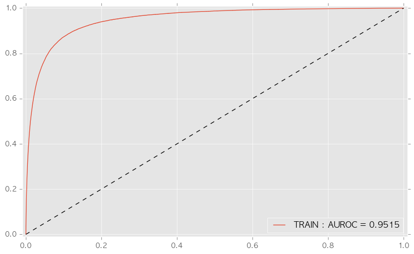

```python
from sklearn.metrics import roc_curve, auc
x_train = train_x; y_train = np.array([int(y) for y in train_y])
pred_probas_train = toy_dense_risk_model.predict_proba(x_train)[:,1]

fpr_train,tpr_train , _ = roc_curve(y_train, pred_probas_train)
roc_auc_train = auc(fpr_train,tpr_train)

plt.plot(fpr_train,tpr_train,label='TRAIN : AUROC = %.4f' %roc_auc_train)
plt.plot([0, 1], [0, 1], 'k--'); plt.xlim([-0.01, 1.01]); plt.ylim([-0.01, 1.01]); plt.legend(loc='lower right')
plt.show()
```

```python
# 시간이 오래걸리는 결과물은 pickle로 쓰고 다음에 작업할때는 pickle로 불러 옵시다.
import pickle
#with open('toy_dense_risk_model', 'wb') as f:
#    pickle.dump(toy_dense_risk_model, f)
#del XY_name, train_x, train_y, toy_dense_risk_model

with open ('toy_dense_risk_model', 'rb') as f:
    toy_dense_risk_model = pickle.load(f)
```

```python
data = [['대형 공사계약', '2'], ['대형 판매계약', '2'], ['대형 매출계약', '2'] ]
doc_all   = [(tokenize(row[0]),row[1]) for row in data ]
TaggedDocumnet = namedtuple("TaggedDocument","words tags")
qlist = [TaggedDocument(a,b) for a,b in doc_all]

test_x = []
for doc in qlist:
    toy_dense_model.random.seed(1234)
    test_x.append(toy_dense_model.infer_vector(doc.words))
print(toy_dense_risk_model.predict_proba(test_x)[:,1])
```

```
[ 0.04501267  0.04485619  0.04245259]
```

```python
data = [ ['영업부진 지속', '2'], ['대표이사 배임 횡령 주가 급락', '2'], ['법정관리와 워크아웃 기로에서 우왕좌왕', '2'] ]
doc_all   = [(tokenize(row[0]),row[1]) for row in data ]
TaggedDocumnet = namedtuple("TaggedDocument","words tags")
qlist = [TaggedDocument(a,b) for a,b in doc_all]

test_x = []
for doc in qlist:
    toy_dense_model.random.seed(1234)
    test_x.append(toy_dense_model.infer_vector(doc.words))
print(toy_dense_risk_model.predict_proba(test_x)[:,1])
```

```
[ 0.04876137  0.06677477  0.08226433]
```

# 8. Word2Vec & Doc2Vec

### - Word2Vec & Doc2Vec 설계

[figure not shown]

- Doc2Vec : -PV-DM(distributed memeory) - PV-DBOW(distributed bag of words)
- Word2Vec : -CBOW(continuous bag of words) - Skip-gram
- $c \in \mathbb{R}^{1 \cdot V} $: $word_i$ 의 주변 맥락 단어 벡터(one-hot-encoding), $k$개 까지 고려, $V$는 단어사전의 크기
- $d \in \mathbb{R}^{1 \cdot N} $: 문서의 id 벡터(one-hot-encoding), N은 문서의 개수
- $h \in \mathbb{R}^{1 \cdot P} $: hidden layer 벡터($= c\cdot\hat{W}$, = $d\cdot\hat{M}$), P는 hyper-parameter로 문서를 표현하는 벡터 크기
- $y \in \mathbb{R}^{1 \cdot V} $: output layer로 단어 등장에 대한 예측 확률값 벡터 $ \approx \hat{U}\cdot h$
- $\hat{W} \in \mathbb{R}^{V \cdot P} $: 단어 input layer -> hidden layer 가중치 행렬
- $\hat{M} \in \mathbb{R}^{N \cdot P} $: 문서 input layer -> hidden layer 가중치 행렬
- $\hat{U} \in \mathbb{R}^{P \cdot V} $: hidden layer -> output layer 가중치 행렬, 즉 단어별로는 $P \cdot 1$의 벡터가 할당